# Album Clustering

Daniel DeFoe

## Data Subset Creations

One dataset is made to include only the average of all the subjective spotify measures and then another is made to include more expressions(maximums and ranges) of some of these measures.

TODO: Will try to create a function to get the more basic genres of an album. (Ex: Rock, Pop, Country, Rap, Hip-hop, R&B, Electronic, EDM, Singer-Songwriter, Alternative, Jazz, Blues, Instrumental, Live, Metal)

## PCA

First, PCA was applied to the smaller subest of averages only of the spotify metrics.

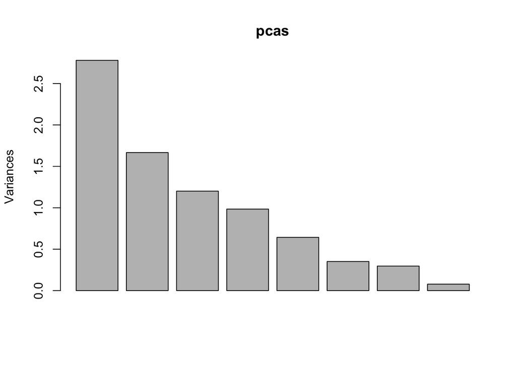

```
##                              PC1        PC2         PC3          PC4
## avgAcousticness      0.464093235 -0.2591597  0.08366390 -0.314841479
## avgDanceability     -0.300895574 -0.5366099 -0.19679115  0.235693092
## avgEnergy           -0.503956561  0.3540527  0.08519102  0.097818088
## avgInstrumentalness  0.219676062  0.2575536 -0.17259265  0.793985519
## avgLiveness         -0.009433991  0.1634276  0.82070908 -0.004737166
## avgLoudness         -0.489726434  0.2744720 -0.09820384 -0.256780059
## avgSpeechiness      -0.162967986 -0.4191997  0.48020645  0.366168266
## avgValence          -0.354076249 -0.4188402 -0.05849993 -0.072832604
##                             PC5
## avgAcousticness      0.21357045
## avgDanceability      0.07058972
## avgEnergy            0.07442516
## avgInstrumentalness  0.32516768
## avgLiveness          0.38998566
## avgLoudness         -0.07940641
## avgSpeechiness      -0.50828930
## avgValence           0.64913745
```

Here we will define that the PC’s as follows: - PC1: How low energy, and acoustic an album is - PC2: Relatively neutral and poorly defined component - PC3: How very likely something is a live album - PC4: How instrumentally heavy and speech heavy an album is - PC5: How live, instrumental, and happy an album is

Next, PCA was applied to the larger collection of functions of the spotify metrics.

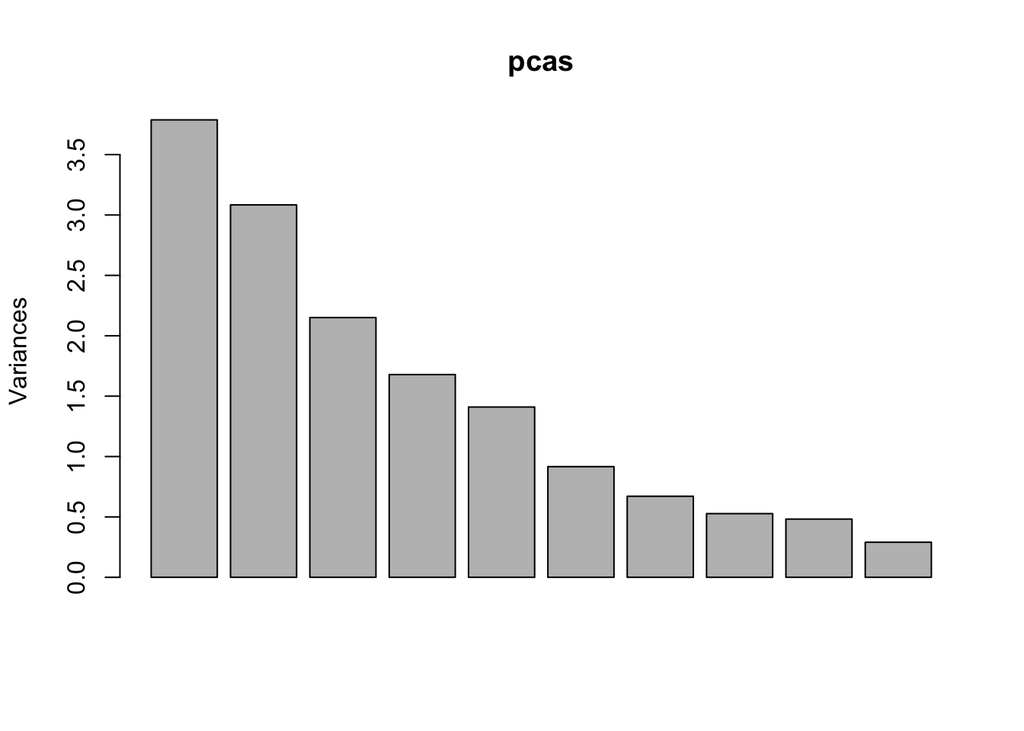

```
##                                  PC1         PC2         PC3         PC4
## avgAcousticness           0.35881347 -0.15462025  0.17698319 -0.29774864
## maxAcousticnessTrack      0.32724281 -0.25926806  0.05976171 -0.15295550
## avgDanceability          -0.31085466 -0.28372879  0.25832128  0.18500057
## maxDanceabilityTrack     -0.24294799 -0.36523551  0.22552772  0.20025972
## rangeEnergy               0.21727179 -0.22265152 -0.07778742  0.16957933
## avgEnergy                -0.35911031  0.19843851 -0.29067284  0.16136507
## maxInstrumentalnessTrack  0.21564287  0.06711972 -0.18482466  0.54848632
## avgInstrumentalness       0.21570573  0.09172705 -0.13562855  0.53689306
## avgLiveness               0.01132331 -0.05925965 -0.54456665 -0.25527743
## maxLivenessTrack         -0.04545989 -0.16643120 -0.54362710 -0.11472413
## avgLoudness              -0.36014361  0.20422545 -0.07920968  0.02043610
## rangeLoudness             0.23278577 -0.33120912 -0.12621303  0.20439255
## avgSpeechiness           -0.18955610 -0.38232328 -0.17172132 -0.07689836
## maxSpeechinessTrack      -0.14582513 -0.43259343 -0.19508511 -0.01840107
## avgValence               -0.30903338 -0.16790918  0.14208183  0.01616203
## rangeValence             -0.02295826 -0.22132097  0.04894060  0.20663652
##                                  PC5
## avgAcousticness           0.07665129
## maxAcousticnessTrack     -0.24131209
## avgDanceability           0.10654223
## maxDanceabilityTrack      0.06405667
## rangeEnergy              -0.52163024
## avgEnergy                -0.19931299
## maxInstrumentalnessTrack  0.13799797
## avgInstrumentalness       0.29295138
## avgLiveness               0.01037135
## maxLivenessTrack         -0.02567453
## avgLoudness              -0.35156628
## rangeLoudness            -0.12697660
## avgSpeechiness            0.30823524
## maxSpeechinessTrack       0.19602007
## avgValence               -0.08673357
## rangeValence             -0.47149403
```

Next, PCA was applied to the data with all spotify metrics and the objective average metrics.

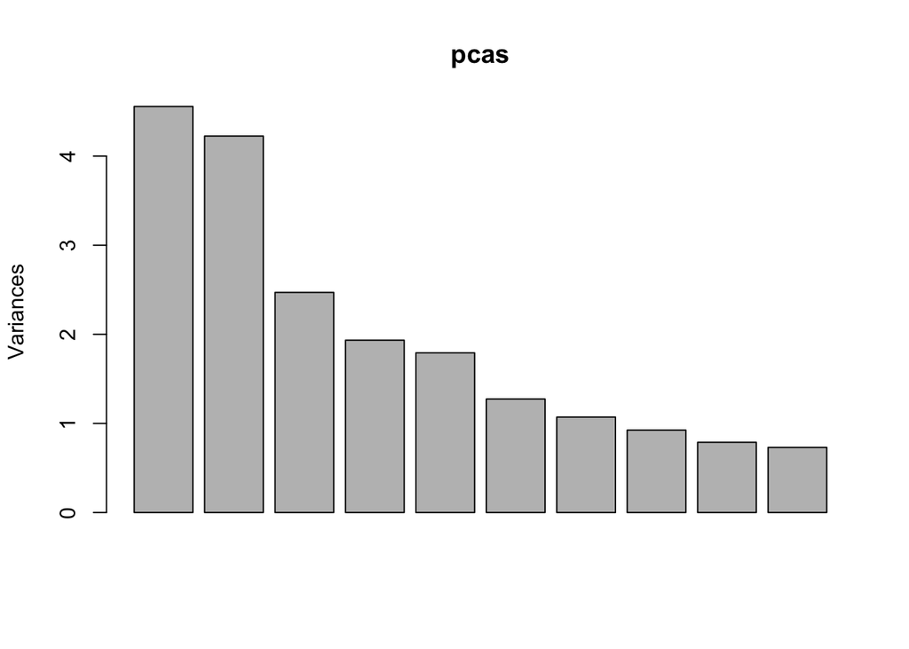

```
##                                   PC1         PC2          PC3
## numSongsOnAlb             0.169144421  0.22271157 -0.262738305
## totalDurationSeconds      0.074507839  0.16658534 -0.370757647
## avgTempo                 -0.123650953 -0.16801264 -0.165130913
## rangeTempo                0.105662580  0.19380664  0.023532329
## moreCommonMajMin         -0.079460165  0.02892098  0.011439973
## presenceUncommonTS       -0.047505313 -0.23677569 -0.005578516
## totalExplicit             0.383539056  0.01324263 -0.029081059
## proportionExplicit        0.371796298 -0.03329260  0.013286018
## avgAcousticness          -0.092169781  0.33557397  0.264368408
## maxAcousticnessTrack     -0.004183538  0.37037854  0.140339987
## avgDanceability           0.285075732 -0.16861980  0.225496009
## maxDanceabilityTrack      0.320735203 -0.06164779  0.204973680
## rangeEnergy               0.023782003  0.27978979 -0.067241123
## avgEnergy                 0.064571972 -0.33650113 -0.354112691
## maxInstrumentalnessTrack -0.127382845  0.14665945 -0.254640844
## avgInstrumentalness      -0.140654755  0.12339197 -0.208441096
## avgLiveness               0.074324347  0.07737097 -0.374833463
## maxLivenessTrack          0.174014404  0.08213442 -0.396638515
## avgLoudness               0.036991034 -0.34635361 -0.168360402
## rangeLoudness             0.113894615  0.32742330 -0.035037456
## avgSpeechiness            0.392017481  0.01688582  0.017284657
## maxSpeechinessTrack       0.390759898  0.07844367 -0.021790388
## avgValence                0.195857041 -0.18223524  0.124393694
## rangeValence              0.131169849  0.09410718 -0.014256328
##                                   PC4         PC5
## numSongsOnAlb             0.156541719 -0.23164481
## totalDurationSeconds      0.234720696 -0.13990613
## avgTempo                  0.013317887 -0.13925015
## rangeTempo               -0.241324395 -0.25985449
## moreCommonMajMin         -0.115467224 -0.24859029
## presenceUncommonTS        0.184362056  0.06483555
## totalExplicit            -0.075619480  0.16366721
## proportionExplicit       -0.099361867  0.22690155
## avgAcousticness          -0.126219992  0.01905263
## maxAcousticnessTrack     -0.046596594 -0.15673390
## avgDanceability           0.328136223 -0.03864759
## maxDanceabilityTrack      0.330673581 -0.07071559
## rangeEnergy               0.138068389 -0.29345718
## avgEnergy                -0.007669482 -0.11973195
## maxInstrumentalnessTrack  0.375066430  0.25040019
## avgInstrumentalness       0.382353594  0.37276433
## avgLiveness              -0.329846710  0.05536548
## maxLivenessTrack         -0.195896143  0.01648279
## avgLoudness              -0.051727974 -0.28205987
## rangeLoudness             0.136571893  0.01064065
## avgSpeechiness           -0.127042121  0.21467813
## maxSpeechinessTrack      -0.063297865  0.12520563
## avgValence                0.130445594 -0.25359322
## rangeValence              0.228684950 -0.39111386
```

Here we will define that the PC’s as follows: - PC1: Measure of how explicit an album is compiled with how dancable and speechy it is, potentially a score of something being a rap album - PC2: Measure of how low energy, low volume, high dynamic, and acoustic an album is. - PC3: How short an album is, with also measuring how acoustic and dancable it is. - PC4: Measure of how long, instrumental, happy, and dancable an album is that is not live - PC5: Measure of how short, explicit, instrumental, slow, and sad an album is.

## K-Means Clustering and Case Studies

What will really be focused on here is the clustering of the PC’s as this will reduce the affect of the noise.

A function will be created to join the demographic and objective data back to the album names once they have been clustered. This will allow us to see the prevalence of traits in particular clusters.

The principle components of only the average spotify metrics are clustered.

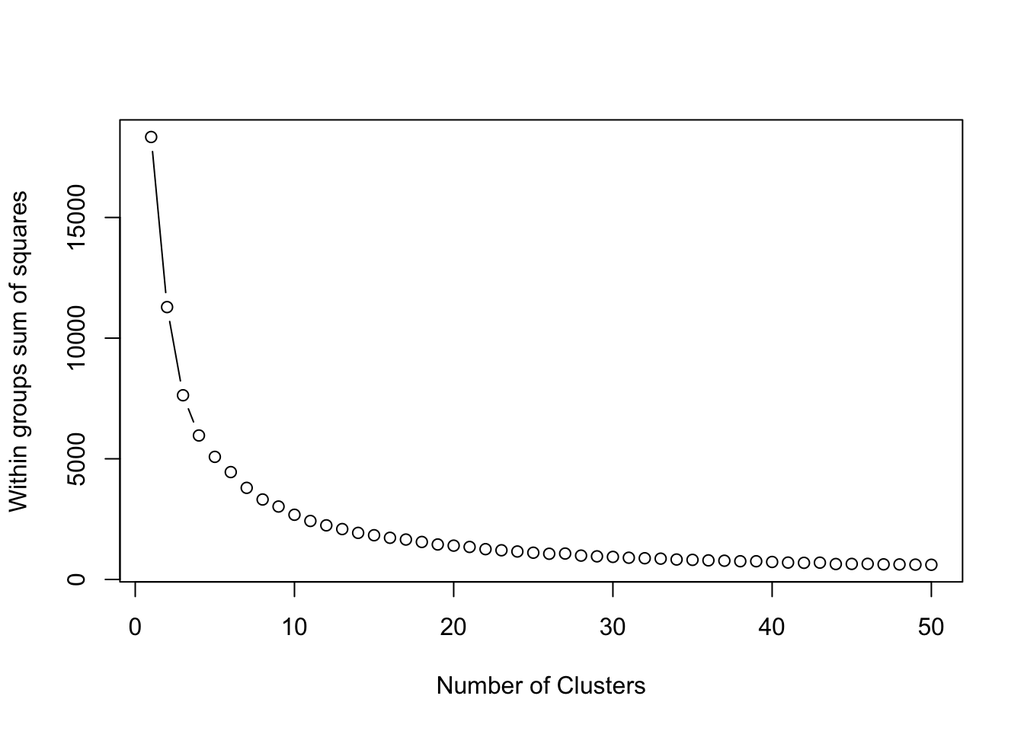

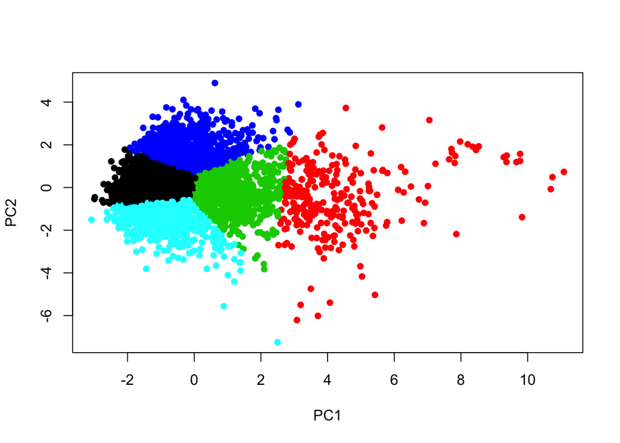

```
## # A tibble: 15 x 3
## # Groups:   cluster [5]
##    cluster Gender countInClusts
##    <fct>   <chr>          <int>
##  1 1       F                260
##  2 1       M                920
##  3 1       <NA>              81
##  4 2       F                 93
##  5 2       M                200
##  6 2       <NA>              12
##  7 3       F                261
##  8 3       M                599
##  9 3       <NA>              42
## 10 4       F                 97
## 11 4       M                588
## 12 4       <NA>              72
## 13 5       F                103
## 14 5       M                767
## 15 5       <NA>              30
```

```
## # A tibble: 3 x 3
## # Groups:   cluster [3]
##   cluster Artist     countInClusts
##   <fct>   <chr>              <int>
## 1 1       John Mayer             1
## 2 2       John Mayer             2
## 3 3       John Mayer             4
```

```
## # A tibble: 2 x 3
## # Groups:   cluster [2]
##   cluster Artist   countInClusts
##   <fct>   <chr>            <int>
## 1 1       Maroon 5             4
## 2 3       Maroon 5             1
```

The principle components of the complete set of spotify metrics are clustered here using k-means.

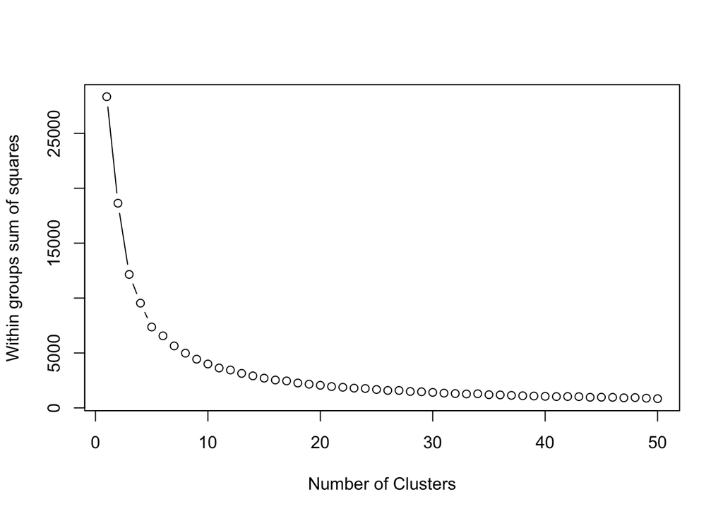

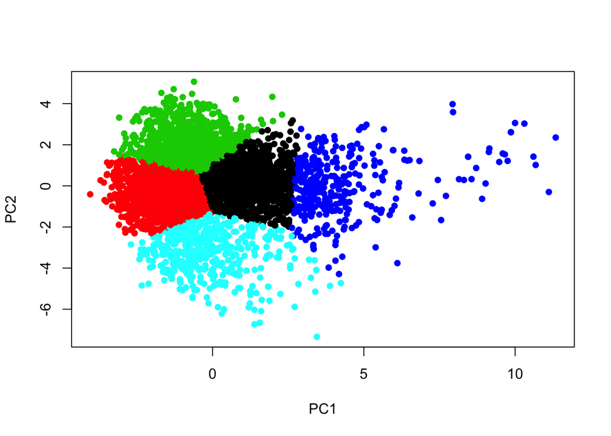

```
## # A tibble: 3 x 3
## # Groups:   cluster [3]
##   cluster Artist     countInClusts
##   <fct>   <chr>              <int>
## 1 1       John Mayer             4
## 2 3       John Mayer             1
## 3 4       John Mayer             2
```

```
## # A tibble: 2 x 3
## # Groups:   cluster [2]
##   cluster Artist   countInClusts
##   <fct>   <chr>            <int>
## 1 2       Maroon 5             4
## 2 5       Maroon 5             1
```

The principle components of the complete set of spotify metrics and the objective measures are clustered here using k-means.

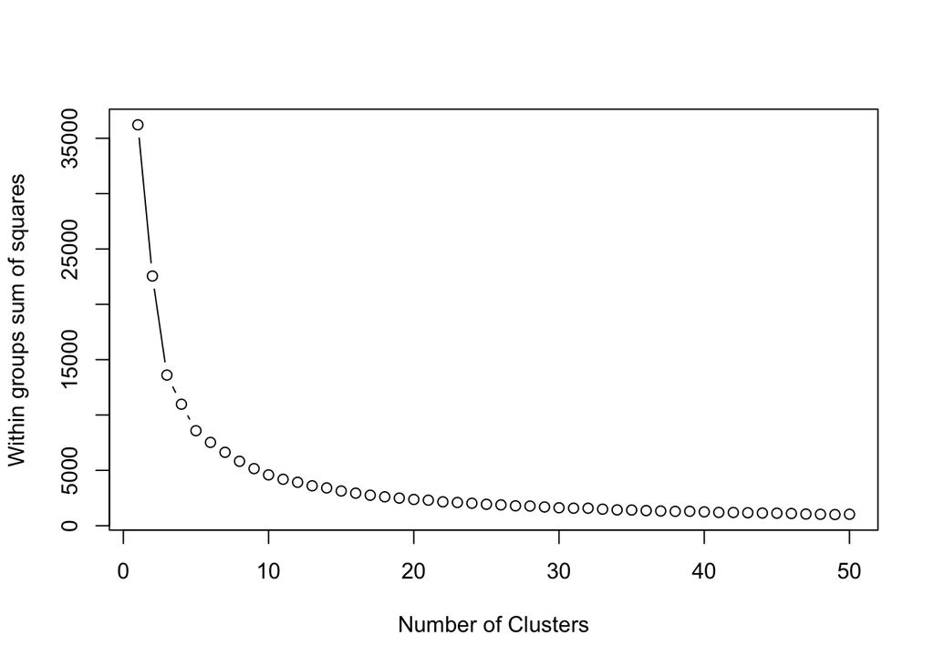

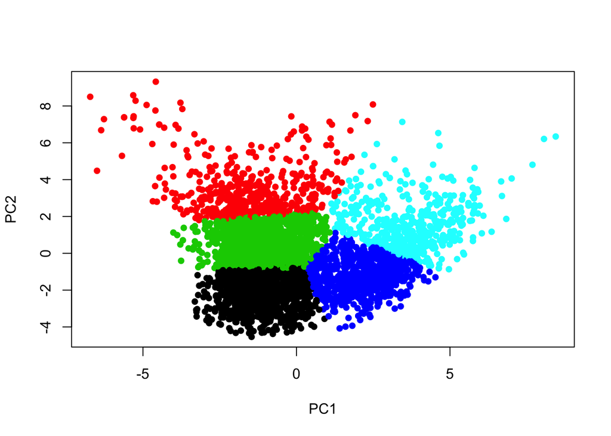

```
## # A tibble: 3 x 3
## # Groups:   cluster [3]
##   cluster Artist     countInClusts
##   <fct>   <chr>              <int>
## 1 1       John Mayer             1
## 2 2       John Mayer             2
## 3 3       John Mayer             4
```

```
## # A tibble: 4 x 3
## # Groups:   cluster [4]
##   cluster Artist   countInClusts
##   <fct>   <chr>            <int>
## 1 1       Maroon 5             1
## 2 3       Maroon 5             2
## 3 4       Maroon 5             1
## 4 5       Maroon 5             1
```